# 第二章 R语言数据操作

中国人民大学 统计学院  
周静

# 数据结构：矩阵

- 将向量摞起来

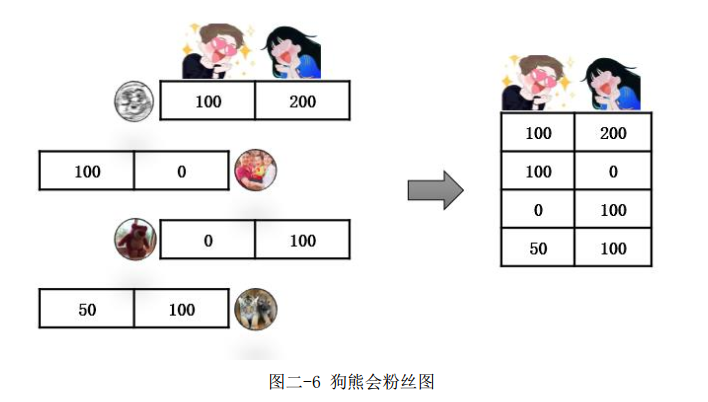

- 矩阵是一个二维数组，外表类似于 excel 中的表格
- 每个元素都必须拥有**相同的数据类型**
- 是在各种数学模拟运算中用到最多的数据结构

# 矩阵：基本操作

- 创建与引用

```r
#生成全部是0的矩阵
zero=matrix(0,nrow=3,ncol=3);zero
##      [,1] [,2] [,3]
## [1,]    0    0    0
## [2,]    0    0    0
## [3,]    0    0    0
#生成一个对角全是1的矩阵,直接在diag中输入对角线向量即可
dig=diag(rep(1,4));dig
##      [,1] [,2] [,3] [,4]
## [1,]    1    0    0    0
## [2,]    0    1    0    0
## [3,]    0    0    1    0
## [4,]    0    0    0    1
#从已有数据转化成矩阵
M = matrix(1:12, nrow = 3, ncol = 4);M
##      [,1] [,2] [,3] [,4]
## [1,]    1    4    7   10
## [2,]    2    5    8   11
## [3,]    3    6    9   12
N= diag(1:4);N
##      [,1] [,2] [,3] [,4]
## [1,]    1    0    0    0
## [2,]    0    2    0    0
## [3,]    0    0    3    0
## [4,]    0    0    0    4
```

- 矩阵概览

```r
#查看矩阵的维度
dim(M)
## [1] 3 4
#提取矩阵的行数
nrow(M)
## [1] 3
#提取矩阵的列数
ncol(M)
## [1] 4
#引用元素
M[1,2]
## [1] 4
M[1:2,2:3]
##      [,1] [,2]
## [1,]    4    7
## [2,]    5    8
#给行列命名
colnames(M)=paste0("x_",1:4)
rownames(M)=1:3;M
##   x_1 x_2 x_3 x_4
## 1   1   4   7  10
## 2   2   5   8  11
## 3   3   6   9  12
#同样的命令可调用行列名
colnames(M)
## [1] "x_1" "x_2" "x_3" "x_4"
rownames(M)
## [1] "1" "2" "3"

#将多个矩阵合并
A= matrix(1:9, nrow = 3, ncol = 3,byrow = T);A
##      [,1] [,2] [,3]
## [1,]    1    2    3
## [2,]    4    5    6
## [3,]    7    8    9
B= diag(11:13);B
##      [,1] [,2] [,3]
## [1,]   11    0    0
## [2,]    0   12    0
## [3,]    0    0   13
rbind(A,B)
##      [,1] [,2] [,3]
## [1,]    1    2    3
## [2,]    4    5    6
## [3,]    7    8    9
## [4,]   11    0    0
## [5,]    0   12    0
## [6,]    0    0   13
cbind(A,B)
##      [,1] [,2] [,3] [,4] [,5] [,6]
## [1,]    1    2    3   11    0    0
## [2,]    4    5    6    0   12    0
## [3,]    7    8    9    0    0   13
```

# 矩阵：数学操作

- 数学操作函数

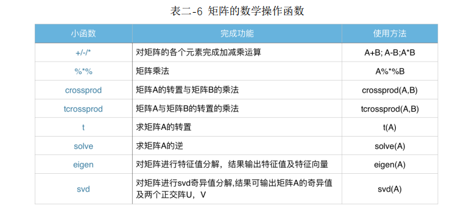

- 计算结果

```r
#矩阵的加减乘运算
A+B
##      [,1] [,2] [,3]
## [1,]   12    2    3
## [2,]    4   17    6
## [3,]    7    8   22
A-B
##      [,1] [,2] [,3]
## [1,]  -10    2    3
## [2,]    4   -7    6
## [3,]    7    8   -4
A*B
##      [,1] [,2] [,3]
## [1,]   11    0    0
## [2,]    0   60    0
## [3,]    0    0  117
A %*% B
##      [,1] [,2] [,3]
## [1,]   11   24   39
## [2,]   44   60   78
## [3,]   77   96  117
```

# rARPACK:大规模矩阵运算

- 这个R包可以提高大规模矩阵的运算效率(例如：矩阵求逆，特征值、奇异值求解等)。
- 仅对矩阵计算一部分有代表性的特征值（奇异值）来近似分解，类似于主成分分析中只选取前几个主成分来概括原始信息的思想。
- 对比实例

```r
#打开这个包
library(rARPACK)
#构造一个1000维的大型矩阵
T=matrix(1:1000000,1000,1000)
#正常分解与快速分解的对比，此处以选择前5个特征（奇异）值为例
system.time(svd(T))
##    user  system elapsed
##    2.44    0.00    2.44
system.time(svds(T,5))
##    user  system elapsed
##    0.07    0.00    0.07
system.time(eigen(T))
##    user  system elapsed
##    4.45    0.02    4.47
system.time(eigs(T,5))
##    user  system elapsed
##    0.23    0.00    0.24

#矩阵的转置、求逆及分解
solve(B) #求矩阵逆
##            [,1]       [,2]       [,3]
## [1,] 0.09090909 0.00000000 0.00000000
## [2,] 0.00000000 0.08333333 0.00000000
## [3,] 0.00000000 0.00000000 0.07692308
t(A)     #求矩阵转置
##      [,1] [,2] [,3]
## [1,]    1    4    7
## [2,]    2    5    8
## [3,]    3    6    9
eigen(A) #特征值分解
## eigen() decomposition
## $values
## [1]  1.611684e+01 -1.116844e+00 -1.303678e-15
##
## $vectors
##            [,1]        [,2]       [,3]
## [1,] -0.2319707 -0.78583024  0.4082483
## [2,] -0.5253221 -0.08675134 -0.8164966
## [3,] -0.8186735  0.61232756  0.4082483
svd(A)   #奇异值svd分解
## $d
## [1] 1.684810e+01 1.068370e+00 4.418425e-16
##
## $u
##            [,1]       [,2]       [,3]
## [1,] -0.2148372  0.8872307  0.4082483
## [2,] -0.5205874  0.2496440 -0.8164966
## [3,] -0.8263375 -0.3879428  0.4082483
##
## $v
##            [,1]        [,2]       [,3]
## [1,] -0.4796712 -0.77669099 -0.4082483
## [2,] -0.5723678 -0.07568647  0.8164966
## [3,] -0.6650644  0.62531805 -0.4082483
```

# 稀疏矩阵

- 定义：矩阵所包含的元素中，数值为 0 的元素远远多于非 0 元素。
- 示例：把微博上用户之间的关注数据抽象成邻接矩阵 A

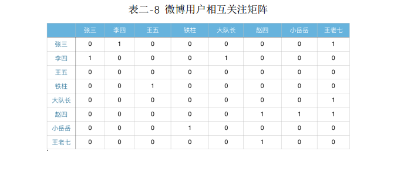

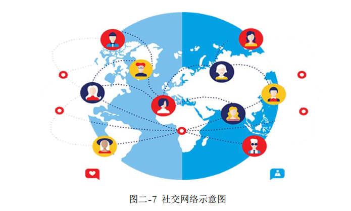

- 稀疏矩阵的生成

```r
library(Matrix)
#生成普通矩阵
vector=c(1:3,rep(0,5),6:9)
m1 <- matrix(vector, nrow = 3, ncol = 4);m1
##      [,1] [,2] [,3] [,4]
## [1,]    1    0    0    7
## [2,]    2    0    0    8
## [3,]    3    0    6    9
#生成稀疏矩阵方法1
m2 <- Matrix(vector, nrow = 3 ,ncol = 4, sparse = TRUE);m2
## 3 x 4 sparse Matrix of class "dgCMatrix"
##
## [1,] 1 . . 7
## [2,] 2 . . 8
## [3,] 3 . 6 9
m3 <- Matrix(vector, nrow = 3 ,ncol = 4, sparse = FALSE);m3
## 3 x 4 Matrix of class "dgeMatrix"
##      [,1] [,2] [,3] [,4]
## [1,]    1    0    0    7
## [2,]    2    0    0    8
## [3,]    3    0    6    9
#生成稀疏矩阵方法2
m4<- spMatrix(10,20, i = c(1,3:8), j = c(2,9,6:10),x = 7 * (1:7))
m4
## 10 x 20 sparse Matrix of class "dgTMatrix"
##
##  [1,] . 7 . . .  .  .  .  .  . . . . . . . . . . .
##  [2,] . . . . .  .  .  .  .  . . . . . . . . . . .
##  [3,] . . . . .  .  .  . 14  . . . . . . . . . . .
##  [4,] . . . . . 21  .  .  .  . . . . . . . . . . .
##  [5,] . . . . .  . 28  .  .  . . . . . . . . . . .
##  [6,] . . . . .  .  . 35  .  . . . . . . . . . . .
##  [7,] . . . . .  .  .  . 42  . . . . . . . . . . .
##  [8,] . . . . .  .  .  .  . 49 . . . . . . . . . .
##  [9,] . . . . .  .  .  .  .  . . . . . . . . . . .
## [10,] . . . . .  .  .  .  .  . . . . . . . . . . .
```

# 稀疏矩阵：优势

- 内存优势

```r
#行列数分别为10时，稀疏矩阵的内存大小和生成时间都比正常矩阵还差。
n=10
m1 <- matrix(0, nrow = n, ncol = n)
m2 <- Matrix(0, nrow = n ,ncol = n, sparse = TRUE)
object.size(m1)
## 1016 bytes
object.size(m2)
## 1768 bytes
system.time(matrix(0, nrow = n, ncol = n))
##    user  system elapsed
##       0       0       0
system.time(Matrix(0, nrow = n ,ncol = n, sparse = TRUE))
##    user  system elapsed
##       0       0       0
#行列数分别为100时，稀疏矩阵在内存优势已经很大了，但生成时间还略有落后
n=100
m1 <- matrix(0, nrow = n, ncol = n)
m2 <- Matrix(0, nrow = n ,ncol = n, sparse = TRUE)
object.size(m1);object.size(m2)
## 80216 bytes
## 2128 bytes
system.time(matrix(0, nrow = n, ncol = n))
##    user  system elapsed
##       0       0       0
system.time(Matrix(0, nrow = n ,ncol = n, sparse = TRUE))
##    user  system elapsed
##    0.01    0.00    0.01

#行列数分别为1000时，普通矩阵就完全不是稀疏矩阵的对手了。
n=1000
m1 <- matrix(0, nrow = n, ncol = n)
m2 <- Matrix(0, nrow = n ,ncol = n, sparse = TRUE)
object.size(m1);object.size(m2)
## 8000216 bytes
## 5728 bytes
system.time(matrix(0, nrow = n, ncol = n))
##    user  system elapsed
##       0       0       0
system.time(Matrix(0, nrow = n ,ncol = n, sparse = TRUE))
##    user  system elapsed
##       0       0       0
```

- 运算优势

```r
n=1000
dat=sample(c(0,1),n^2,replace = TRUE,prob = c(0.9,0.1))
m1=matrix(dat, nrow = n, ncol = n);m1[1:6,1:6]
##      [,1] [,2] [,3] [,4] [,5] [,6]
## [1,]    1    0    0    0    0    0
## [2,]    0    0    0    0    0    0
## [3,]    0    0    0    1    0    0
## [4,]    0    0    0    0    0    0
## [5,]    0    0    0    0    0    0
## [6,]    1    0    0    0    0    0
m2=Matrix(dat, nrow = n ,ncol = n ,sparse = TRUE);m2[1:6,1:6]
## 6 x 6 sparse Matrix of class "dgCMatrix"
##
## [1,] 1 . . . . .
## [2,] . . . . . .
## [3,] . . . 1 . .
## [4,] . . . . . .
## [5,] . . . . . .
## [6,] 1 . . . . .
#求乘积运算时间对比
system.time(m1%*%t(m1))
##    user  system elapsed
##    0.65    0.00    0.66
system.time(m2%*%t(m1))
##    user  system elapsed
##    0.11    0.00    0.11
#求逆运算时间对比
system.time(solve(m1))
##    user  system elapsed
##    0.97    0.00    0.97
system.time(solve(m2))
##    user  system elapsed
##    2.11    0.03    2.14
```

# 数据框

- 最常见的数据结构
- 从 csv 或 txt文件读入时会自动存储为数据框对象
- 表格状（与矩阵不同，可以存储多种数据类型）
- 每一列须是同一种数据类型
- 基本操作（以movie 电影数据集为例）

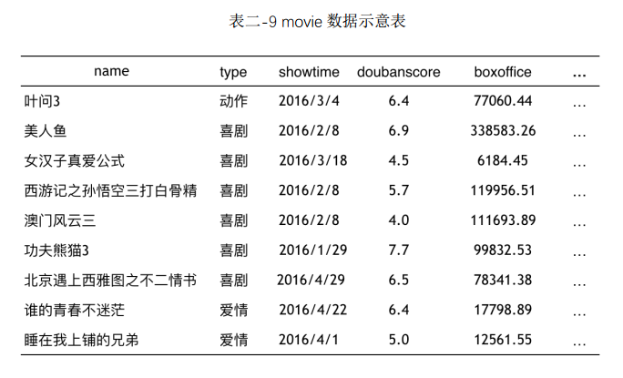

# 数据框：基本操作

- 创建数据框

```r
#读入一个txt,csv等格式数据,即自成一个数据框
#setwd("../data/")
movie=read.csv("电影数据.csv",fileEncoding = "GBK",stringsAsFactors = F)
class(movie)
## [1] "data.frame"

#自己创建
star1=c("邓超","赵丽颖","郭富城","周润发","杰克布莱克","汤唯","白敬亭","陈晓","梁家辉","姚晨","宋茜","黄宗泽","黄晓明")
birthyear=c(1980,1987,1977,1987,1958,1987,1979,1953,1987,1993,1952,1976,1963)
gender=c("男","女","男","女","男","女","女","男","男","男","男","男","男")
stars=data.frame(star1,birthyear,gender);stars
##         star1 birthyear gender
## 1        邓超      1980     男
## 2      赵丽颖      1987     女
## 3      郭富城      1977     男
## 4      周润发      1987     女
## 5  杰克布莱克      1958     男
## 6        汤唯      1987     女
## 7      白敬亭      1979     女
## 8        陈晓      1953     男
## 9      梁家辉      1987     男
## 10       姚晨      1993     男
## 11       宋茜      1952     男
## 12     黄宗泽      1976     男
## 13     黄晓明      1963     男
```

- 汇总

```r
str(movie)
## 'data.frame':    19 obs. of  11 variables:
##  $ name       : chr  "叶问3" "美人鱼" "女汉子真爱公式" "西游记之孙悟空三打白骨精" ...
##  $ boxoffice  : num  77060 338583 6184 119957 111694 ...
##  $ doubanscore: num  6.4 6.9 4.5 5.7 4 7.7 6.5 6.4 5 5.6 ...
##  $ type       : chr  "动作" "喜剧" "喜剧" "喜剧" ...
##  $ duration   : int  105 93 93 120 112 95 131 108 95 102 ...
##  $ showtime   : chr  "2016/3/4" "2016/2/8" "2016/3/18" "2016/2/8" ...
##  $ director   : chr  "叶伟信" "周星驰" "郭大雷" "郑保瑞" ...
##  $ star1      : chr  "甄子丹" "邓超" "赵丽颖" "郭富城" ...
##  $ index1     : int  11385 41310 181979 12227 16731 178 13499 14759 13251 6911 ...
##  $ star2      : chr  "张晋" "林允" "张翰" "巩俐" ...
##  $ index2     : int  4105 9292 44277 8546 30277 1540 77260 755 9549 5614 ...
summary(movie)
##      name             boxoffice         doubanscore        type
##  Length:19          Min.   :   924.9   Min.   :3.400   Length:19
##  Class :character   1st Qu.:  3799.5   1st Qu.:4.600   Class :character
##  Mode  :character   Median : 12561.5   Median :5.300   Mode  :character
##                     Mean   : 50813.3   Mean   :5.568
##                     3rd Qu.: 77700.9   3rd Qu.:6.450
##                     Max.   :338583.3   Max.   :8.000
##     duration       showtime           director            star1
##  Min.   : 84.0   Length:19          Length:19          Length:19
##  1st Qu.: 94.5   Class :character   Class :character   Class :character
##  Median : 99.0   Mode  :character   Mode  :character   Mode  :character
##  Mean   :101.5
##  3rd Qu.:107.5
##  Max.   :131.0
##      index1          star2               index2
##  Min.   :   178   Length:19          Min.   :  521
##  1st Qu.:  8232   Class :character   1st Qu.: 3650
##  Median : 12227   Mode  :character   Median : 9292
##  Mean   : 27861                      Mean   :17369
##  3rd Qu.: 24663                      3rd Qu.:20763
##  Max.   :181979                      Max.   :77260
head(movie)
##                       name boxoffice doubanscore type duration  showtime
## 1                    叶问3  77060.44         6.4 动作      105  2016/3/4
## 2                   美人鱼 338583.26         6.9 喜剧       93  2016/2/8
## 3           女汉子真爱公式   6184.45         4.5 喜剧       93 2016/3/18
## 4 西游记之孙悟空三打白骨精 119956.51         5.7 喜剧      120  2016/2/8
## 5               澳门风云三 111693.89         4.0 喜剧      112  2016/2/8
## 6                功夫熊猫3  99832.53         7.7 喜剧       95 2016/1/29
##   director      star1 index1        star2 index2
## 1   叶伟信     甄子丹  11385         张晋   4105
## 2   周星驰       邓超  41310         林允   9292
## 3   郭大雷     赵丽颖 181979         张翰  44277
## 4   郑保瑞     郭富城  12227         巩俐   8546
## 5     王晶     周润发  16731       刘德华  30277
## 6   吕寅荣 杰克布莱克    178 安吉丽娜朱莉   1540
```

# 练习：

```r
L3 = LETTERS[1:3]
fac = sample(L3,10, replace = TRUE)
d = data.frame(x = 1, y = 1:10, fac = fac)
d
##    x  y fac
## 1  1  1   A
## 2  1  2   C
## 3  1  3   A
## 4  1  4   C
## 5  1  5   C
## 6  1  6   B
## 7  1  7   C
## 8  1  8   A
## 9  1  9   C
## 10 1 10   C
```

- 问题1：筛选出d中fac=B的，形成新的数据集dat1
- 问题2：筛选出d中fac=B且y>3的，形成新的新数据集dat2

```r
mm = data.frame(1, 1:10, sample(L3,10, replace = TRUE))
mm
##    X1 X1.10 sample.L3..10..replace...TRUE.
## 1   1     1                              A
## 2   1     2                              B
## 3   1     3                              A
## 4   1     4                              A
## 5   1     5                              B
## 6   1     6                              B
## 7   1     7                              B
## 8   1     8                              B
## 9   1     9                              A
## 10  1    10                              C
```

将mm每列变量重新命名为如下形式

```
##    x_1 x_2 x_3
## 1    1   1   A
## 2    1   2   B
## 3    1   3   A
## 4    1   4   A
## 5    1   5   B
## 6    1   6   B
## 7    1   7   B
## 8    1   8   B
## 9    1   9   A
## 10   1  10   C
```

# 数据框：变变变

- 变大–数据框的增列、合并

```r
#添加一列数据prefer
prefer=1:19
movie$pre=prefer
head(movie)
##                       name boxoffice doubanscore type duration  showtime
## 1                    叶问3  77060.44         6.4 动作      105  2016/3/4
## 2                   美人鱼 338583.26         6.9 喜剧       93  2016/2/8
## 3           女汉子真爱公式   6184.45         4.5 喜剧       93 2016/3/18
## 4 西游记之孙悟空三打白骨精 119956.51         5.7 喜剧      120  2016/2/8
## 5               澳门风云三 111693.89         4.0 喜剧      112  2016/2/8
## 6                功夫熊猫3  99832.53         7.7 喜剧       95 2016/1/29
##   director      star1 index1        star2 index2 pre
## 1   叶伟信     甄子丹  11385         张晋   4105   1
## 2   周星驰       邓超  41310         林允   9292   2
## 3   郭大雷     赵丽颖 181979         张翰  44277   3
## 4   郑保瑞     郭富城  12227         巩俐   8546   4
## 5     王晶     周润发  16731       刘德华  30277   5
## 6   吕寅荣 杰克布莱克    178 安吉丽娜朱莉   1540   6
```

```r
#merge实现的效果是：将movie和stars按照列star1匹配并合并起来
movie.star=merge(movie[1:3,],stars,by="star1");movie.star
##    star1           name boxoffice doubanscore type duration  showtime director
## 1   邓超         美人鱼 338583.26         6.9 喜剧       93  2016/2/8   周星驰
## 2 赵丽颖 女汉子真爱公式   6184.45         4.5 喜剧       93 2016/3/18   郭大雷
##   index1 star2 index2 pre birthyear gender
## 1  41310  林允   9292   2      1980     男
## 2 181979  张翰  44277   3      1987     女

movie.star=merge(movie[1:3,],stars[1:5,],by="star1",all.x = T);movie.star
## Warning in if (all.x) all.x <- (nxx <- length(m$x.alone)) > 0L: 条件的长度大于
## 一，因此只能用其第一元素
##    star1           name boxoffice doubanscore type duration  showtime director
## 1   邓超         美人鱼 338583.26         6.9 喜剧       93  2016/2/8   周星驰
## 2 赵丽颖 女汉子真爱公式   6184.45         4.5 喜剧       93 2016/3/18   郭大雷
## 3 甄子丹          叶问3  77060.44         6.4 动作      105  2016/3/4   叶伟信
##   index1 star2 index2 pre birthyear gender
## 1  41310  林允   9292   2      1980     男
## 2 181979  张翰  44277   3      1987     女
## 3  11385  张晋   4105   1        NA   <NA>
## 你可以试试all.y = T会是什么样？
```

- 变小–数据的筛选、引用

```r
#引用
movie[3,] #查看第3行的电影信息
##             name boxoffice doubanscore type duration  showtime director  star1
## 3 女汉子真爱公式   6184.45         4.5 喜剧       93 2016/3/18   郭大雷 赵丽颖
##   index1 star2 index2 pre
## 3 181979  张翰  44277   3
movie[,8] #查看第8列主演者的名字
##  [1] "甄子丹"     "邓超"       "赵丽颖"     "郭富城"     "周润发"
##  [6] "杰克布莱克" "汤唯"       "白敬亭"     "陈晓"       "梁家辉"
## [11] "姚晨"       "宋茜"       "黄宗泽"     "黄晓明"     "洪金宝"
## [16] "陈坤"       "陶泽如"     "刘亦菲"     "何润东"
#筛选
movie$star1 #用$符号通过列名引用
##  [1] "甄子丹"     "邓超"       "赵丽颖"     "郭富城"     "周润发"
##  [6] "杰克布莱克" "汤唯"       "白敬亭"     "陈晓"       "梁家辉"
## [11] "姚晨"       "宋茜"       "黄宗泽"     "黄晓明"     "洪金宝"
## [16] "陈坤"       "陶泽如"     "刘亦菲"     "何润东"
action=movie[movie$type=="动作",];action #选择数据中的动作电影
##            name boxoffice doubanscore type duration  showtime director  star1
## 1         叶问3  77060.44         6.4 动作      105  2016/3/4   叶伟信 甄子丹
## 10     冰河追凶   4262.14         5.6 动作      102 2016/4/15     徐伟 梁家辉
## 15 我的特工爷爷  32009.37         5.3 动作       99  2016/4/1   洪金宝 洪金宝
## 19         钢刀    924.86         4.3 动作       94 2016/5/20     阿甘 何润东
##    index1  star2 index2 pre
## 1   11385   张晋   4105   1
## 10   6911 佟大为   5614  10
## 15   9148 刘德华  30277  15
## 19  11822 李学东    521  19
action_long=movie[movie$type=="动作" &movie$duration>100,]#放映时间超过100分钟的动作电影#
action_long
##        name boxoffice doubanscore type duration  showtime director  star1
## 1     叶问3  77060.44         6.4 动作      105  2016/3/4   叶伟信 甄子丹
## 10 冰河追凶   4262.14         5.6 动作      102 2016/4/15     徐伟 梁家辉
##    index1  star2 index2 pre
## 1   11385   张晋   4105   1
## 10   6911 佟大为   5614  10
```

- 变序–数据框的内部排序

```r
#按照票房降序排列
movie=movie[order(movie$boxoffice,decreasing = T),];head(movie)
##                       name boxoffice doubanscore type duration  showtime
## 2                   美人鱼 338583.26         6.9 喜剧       93  2016/2/8
## 4 西游记之孙悟空三打白骨精 119956.51         5.7 喜剧      120  2016/2/8
## 5               澳门风云三 111693.89         4.0 喜剧      112  2016/2/8
## 6                功夫熊猫3  99832.53         7.7 喜剧       95 2016/1/29
## 7 北京遇上西雅图之不二情书  78341.38         6.5 喜剧      131 2016/4/29
## 1                    叶问3  77060.44         6.4 动作      105  2016/3/4
##   director      star1 index1        star2 index2 pre
## 2   周星驰       邓超  41310         林允   9292   2
## 4   郑保瑞     郭富城  12227         巩俐   8546   4
## 5     王晶     周润发  16731       刘德华  30277   5
## 6   吕寅荣 杰克布莱克    178 安吉丽娜朱莉   1540   6
## 7   薛晓路       汤唯  13499       吴秀波  77260   7
## 1   叶伟信     甄子丹  11385         张晋   4105   1
#先按电影类型排序，再按照豆瓣评分排序
movie=movie[order(movie$type,movie$doubanscore,decreasing = T),];head(movie)
##                        name boxoffice doubanscore type duration  showtime
## 6                 功夫熊猫3  99832.53         7.7 喜剧       95 2016/1/29
## 2                    美人鱼 338583.26         6.9 喜剧       93  2016/2/8
## 7  北京遇上西雅图之不二情书  78341.38         6.5 喜剧      131 2016/4/29
## 4  西游记之孙悟空三打白骨精 119956.51         5.7 喜剧      120  2016/2/8
## 13                 刑警兄弟   3005.96         5.2 喜剧       97 2016/4/22
## 3            女汉子真爱公式   6184.45         4.5 喜剧       93 2016/3/18
##    director      star1 index1        star2 index2 pre
## 6    吕寅荣 杰克布莱克    178 安吉丽娜朱莉   1540   6
## 2    周星驰       邓超  41310         林允   9292   2
## 7    薛晓路       汤唯  13499       吴秀波  77260   7
## 4    郑保瑞     郭富城  12227         巩俐   8546   4
## 13   戚家基     黄宗泽   9823         金刚   4010  13
## 3    郭大雷     赵丽颖 181979         张翰  44277   3
#一个更直观的小例子
x <- c(1,1,3:1,1:4,3); y <- c(9,9:1);z <- c(2,1:9)
test=data.frame(x,y,z)
test[order(x, y, z),]
##    x y z
## 6  1 5 5
## 5  1 6 4
## 2  1 9 1
## 1  1 9 2
## 7  2 4 6
## 4  2 7 3
## 10 3 1 9
## 8  3 3 7
## 3  3 8 2
## 9  4 2 8
```

- 变形–长宽表互换
- 宽表—>长表

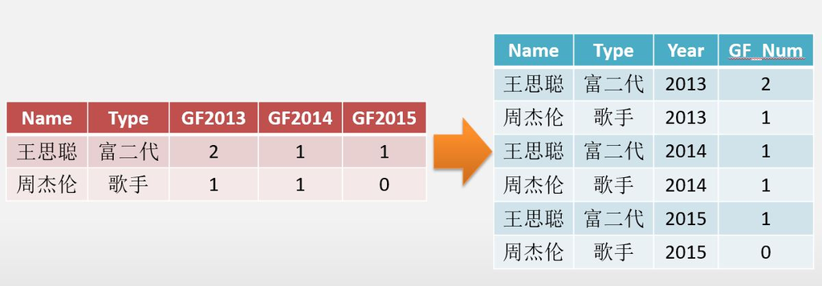

```r
library(reshape)
##
## Attaching package: 'reshape'
## The following object is masked from 'package:Matrix':
##
##     expand
library(reshape2)
##
## Attaching package: 'reshape2'
## The following objects are masked from 'package:reshape':
##
##     colsplit, melt, recast
#宽表变长表
(mWide = data.frame(Name = c("王思聪", "周杰伦"), Type = c("富二代", "歌手") ,
                    GF2013 = c(2,1),GF2014 = c(1,1), GF2015= c(1,0)))
##     Name   Type GF2013 GF2014 GF2015
## 1 王思聪 富二代      2      1      1
## 2 周杰伦   歌手      1      1      0
(mLong = melt(mWide, id.vars = c("Name", "Type"), variable.name = "Year"))
##     Name   Type   Year value
## 1 王思聪 富二代 GF2013     2
## 2 周杰伦   歌手 GF2013     1
## 3 王思聪 富二代 GF2014     1
## 4 周杰伦   歌手 GF2014     1
## 5 王思聪 富二代 GF2015     1
## 6 周杰伦   歌手 GF2015     0
#将列Year中的GF去掉
mLong$Year = gsub("GF", "",mLong$Year)
#将列Year从字符型变成数值型
mLong$Year=as.numeric(mLong$Year)

#长表变宽表
dcast(mLong,Name+Type~Year)
##     Name   Type 2013 2014 2015
## 1 王思聪 富二代    2    1    1
## 2 周杰伦   歌手    1    1    0
```